# Analysis of Rat Sightings in New York City

### Lasya Muthyam, Sriya Peddinti, Trisha Anand, Christina Xu

### Contributions

Trisha worked on parts A-H. Specifically, she worked on planning, exploratory data analysis, visualization, and statistical tests such as ANOVA test across boroughs for the rat sightings dataset. Additionally, she contributed to planning ML model development, and putting together the final writeup & insights.

Sriya worked on the dataset curation and preprocessing, data exploration, and visualization of the income dataset. This involved cleaning and preparing the income and the zipcode-borough dataset. She created a visualization with this merged dataset as a part of data exploration. She also worked to combine and clean the new merged income and rat cleaning dataset to prepare it for ML training.

Lasya actively contributed to all parts A-H. Specifically, she worked on cleaning and analyzing the Rat Sightings dataset and then designed, trained, and created visualizations/metrics for the random forest classifier model that predicts the concentration of rat sightings in an area given the latitude, longitude, location type, Average Income (Dollars), total number of households, and seasonality.

- Introduction
- Data Curation & Sources
- Exploratory Data Analysis
- Primary Analysis, ML Model, & Visualization
- Visualization Analysis
- Insights and Conclusions
- Appendix: Secondary Model

# Introduction

Researching rat sightings in New York City is crucial for addressing pressing safety and hygiene concerns that impact public health and urban living conditions. Rats are known carriers of diseases such as leptospirosis, hantavirus, and Tularemia, which can pose significant risks to human health. By analyzing data on rat sightings, we hope to identify hotspots where infestations are most prevalent, leading to targeted interventions and preventive measures. The chosen Rat Sightings dataset contains data points on over 250k+ rat sightings on 35+ parameters, including time, location, and neighborhoods, providing us with a rich dataset of information on rat populations in New York City.

# Data Curation & Sources

**Main Dataset**: [Rat Sightings Dataset](https://data.cityofnewyork.us/Social-Services/Rat-Sightings/3q43-55fe/about_data): A dataset containing rat sightings (311 service requests) in New York City from 2010 till September 17, 2024, which came from the NYC Open Data website.

**Supplementary Datasets**:

- [Income dataset](https://www.kaggle.com/datasets/claygendron/us-household-income-by-zip-code-2021-2011?resource=download): This dataset contains US household income by zip code from 2021-2011, which is from a US census dataset that we found on Kaggle.
- [Zipcode-Borough](https://data.ny.gov/Government-Finance/New-York-State-ZIP-Codes-County-FIPS-Cross-Referen/juva-r6g2/data): This dataset contains New York State ZIP codes, counties, and FIPS codes from the New York State Office of Information Technology Services.
- [Population Density](https://simplemaps.com/data/us-zips): Population of each ZIP, taken from US census data, and found on the simplemaps website.

# Exploratory Data Analysis

## Part 1: Initial Data Cleaning: Rat Sightings

We will start by cleaning our dataset to remove null values, and narrow our dataset down to certain columns.

First, we import our dataset.

```python
import pandas as pd
import matplotlib.pyplot as plt
from scipy import stats

df = pd.read_csv("Rat_Sightings_20240917.csv", low_memory=False)
```

We filter out unnecessary/sparse columns like "Taxi Pick Up Location", "Bridge Highway Name", etc. This way, we cut the number of columns from 38 to 7 columns.

We are deciding to look at the following important columns: Created Date, Location Type, Incident Zip, Community Board, Borough, Latitude, Longitude.

```python
# Keep only the necessary columns
df = df[['Created Date', 'Location Type', 'Incident Zip', 'Community Board', 'Borough', 'Latitude', 'Longitude']]
```

Next, we remove Boroughs that are "Unspecified" from the dataframe.

```python
# Drop rows with unspecified boroughs
df = df[df['Borough'] != 'Unspecified']
df.reset_index(drop=True, inplace=True)
```

```python
df.dropna(subset=['Created Date', 'Location Type', 'Incident Zip', 'Community Board', 'Borough', 'Latitude', 'Longitude'], inplace=True)
```

Finally, we will map Location Types to non-duplicate category classifications.

```python
# Get unique values in 'Location Type'
unique_location_types = df['Location Type'].unique()

# Define mapping for residential categories
residential_mapping = {
    'Single Room Occupancy (SRO)': 'Single',
    '1-2 Family Dwelling': '1-2 Family Apartment',
    '1-2 FamilyDwelling': '1-2 Family Apartment',
    '3+ Family Apt. Building': '3+ Family',
    '3+ Family Apartment Building': '3+ Family',
    '3+ Family Apt.': '3+ Family',
    '3+Family Apt.': '3+ Family',
    '3+ Family Apt': '3+ Family',
    '1-3 Family Dwelling': '1-3 Family Dwelling',
    '1-3 Family Mixed Use Building': '1-3 Family Mixed',
    '1-2 Family Mixed Use Building': '1-2 Family Mixed',
    '3+ Family Mixed Use Building': '3+ Family Mixed',
    'Private House': 'Private House',
    'Apartment': 'Apartment',
    'Residential Property': 'Residential Property'
}

# Apply mapping to the 'Location Type' column for residential data
df['Location Type'] = df['Location Type'].replace(residential_mapping)
```

Now that we have done the initial cleaning of our dataset, lets proceed forward and visualize how rat sightings compare across location, time, and income level.

## Part 2: General EDA & Characteristics of Data

Next, we will continue cleaning our dataset while getting key insights on our data results.

### Main Characteristics

```python
# Rough overview of features we want to consider (main characteristics of dataset)

# All boroughs and number of sightings in each
boroughs = df.groupby(['Borough']).groups.keys()
print("*** Boroughs ***")
print(list(boroughs))
mode = df.groupby(['Borough']).count()['Created Date']
print(mode)
```

```
*** Boroughs ***
['BRONX', 'BROOKLYN', 'MANHATTAN', 'QUEENS', 'STATEN ISLAND']
Borough
BRONX            45183
BROOKLYN         92179
MANHATTAN        65173
QUEENS           38457
STATEN ISLAND     9778
Name: Created Date, dtype: int64
```

```python
# All location types and number of sightings in each
location_type = df.groupby(['Location Type']).groups.keys()
print("*** Location Type ***")
print(list(location_type))
mode = df.groupby(['Location Type']).count()['Created Date']
print(mode)
```

```
*** Location Type ***
['1-2 Family Apartment', '1-2 Family Mixed', '1-3 Family Dwelling', '1-3 Family Mixed', '3+ Family', '3+ Family Mixed', 'Abandoned Building', 'Apartment', 'Beach', 'Building (Non-Residential)', 'Cafeteria - Public School', 'Catch Basin/Sewer', 'Catering Service', 'Commercial Building', 'Commercial P…
Location Type
1-2 Family Apartment           47176
1-2 Family Mixed                4124
1-3 Family Dwelling               15
1-3 Family Mixed                   2
3+ Family                     106368
3+ Family Mixed                16387
Abandoned Building                15
Apartment                         82
Beach                              2
Building (Non-Residential)        23
Cafeteria - Public School          1
Catch Basin/Sewer               2310
Catering Service                   1
Commercial Building            13660
Commercial Property                2
Construction Site               5487
Day Care/Nursery                 251
Government Building              514
Grocery Store                      2
Ground                             6
Hospital                         163
Office Building                  236
Other                             71
Other (Explain Below)          38067
Parking Lot/Garage              2662
Private House                      1
Public Garden                   1024
Public Stairs                    200
Residence                         71
Residential Building             215
Residential Property              12
Restaurant                        11
Restaurant/Bar/Deli/Bakery         5
Retail Store                       1
School                             3
School/Pre-School                416
Single                           280
Store                             13
Street Area                      382
Street Fair Vendor                 1
Summer Camp                        8
Vacant Building                 3949
Vacant Lot                      6549
Vacant Lot/Property                2
Name: Created Date, dtype: int64
```

```python
# All zip codes and number of sightings in each (in descending order)
zip_codes = df.groupby(['Incident Zip']).groups.keys()
print("*** Incident Zip Code ***")
print(list(zip_codes))

zip_code_dict = {}
for key in zip_codes:
  zip_code_dict[key] = len(df[df['Incident Zip'] == key])
print("\n(Incident Zip Code , Count) in descending order:")
zip_code_dict = sorted(zip_code_dict.items(), key=lambda item: item[1], reverse=True)
print(zip_code_dict)
```

```
*** Incident Zip Code ***
[83.0, 10000.0, 10001.0, 10002.0, 10003.0, 10004.0, 10005.0, 10006.0, 10007.0, 10009.0, 10010.0, 10011.0, 10012.0, 10013.0, 10014.0, 10016.0, 10017.0, 10018.0, 10019.0, 10020.0, 10021.0, 10022.0, 10023.0, 10024.0, 10025.0, 10026.0, 10027.0, 10028.0, 10029.0, 10030.0, 10031.0, 10032.0, 10033.0, 10034…

(Incident Zip Code , Count) in descending order:
[(11221.0, 6720), (10025.0, 6429), (11216.0, 6342), (11238.0, 6104), (11233.0, 4499), (11385.0, 4471), (11226.0, 4388), (11237.0, 4176), (10467.0, 3986), (11215.0, 3982), (10027.0, 3890), (11207.0, 3810), (11211.0, 3764), (11206.0, 3726), (10456.0, 3660), (10026.0, 3639), (10024.0, 3509), (11213.0, …
```

Considering the number of sightings per zip code, we can observe that the zip code with the greatest number of sightings is in Brooklyn, which is the borough with the greatest number of sightings. Aside from the zip code with the second-highest number of sightings belonging to Manhattan, the other zip codes in the top 5 all belong to Brooklyn.

```python
# Rows, columns
print("(Rows, columns):")
print(df.shape)
```

```
(Rows, columns):
(250770, 7)
```

### Visualizing Residential & Non-Residential Rat Sightings Data

Let's next observe the relationship between rat sightings in residential and non-residential areas. From this visualization, we can see that the proportion of residential rat sightings is much higher than non-residential sightings. This provides us with insight into the makeup of our dataset.

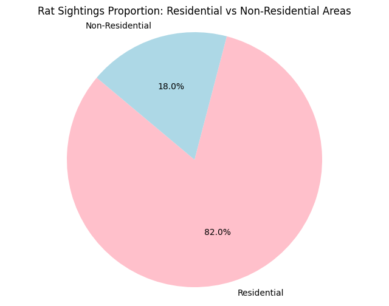

```python
# Create the residential and non-residential DataFrames
residential_df = df[df['Location Type'].isin(residential_mapping.values())]
nonresidential_df = df[~df['Location Type'].isin(residential_mapping.values())]
nonresidential_df = nonresidential_df[~nonresidential_df['Location Type'].isin(['Other', 'Other (Explain Below)'])]

# Basic Data Exploration - residential vs nonresidential pie chart
residential_count = residential_df.shape[0]
nonresidential_count = nonresidential_df.shape[0]

# Data for the pie chart
labels = ['Residential', 'Non-Residential']
sizes = [residential_count, nonresidential_count]
colors = ['pink', 'lightblue']

# Pie chart
plt.figure(figsize=(8, 6))
plt.pie(sizes, labels=labels, colors=colors, autopct='%1.1f%%', startangle=140)
plt.title('Rat Sightings Proportion: Residential vs Non-Residential Areas')
# Equal aspect ratio ensures that pie chart is drawn as a circle.
plt.axis('equal')
plt.show()
```

Next, let's take a look at the geographic density of rat sightings using our Latitude and Longitude data along with frequencies. It can be seen from the map that there are high concentrations of rat sightings located within Manhattan and Brooklyn in particular.

**Insights: Over-representation**

Residential locations had a significantly higher number of reported rat sightings compared to non-residential areas. This is evident from the data: the residential_df contains 175,031 rows, while the nonresidential_df has only 38,665 rows. While this could indicate that rat sightings are more frequent in residential areas, the data may be skewed. People might be more inclined to report rat sightings in private or residential spaces than in non-residential areas or public streets. We thus, need to further investigate why there is such a high discrepency in the number of sightings.

### Visualizing Location of Rat Sightings

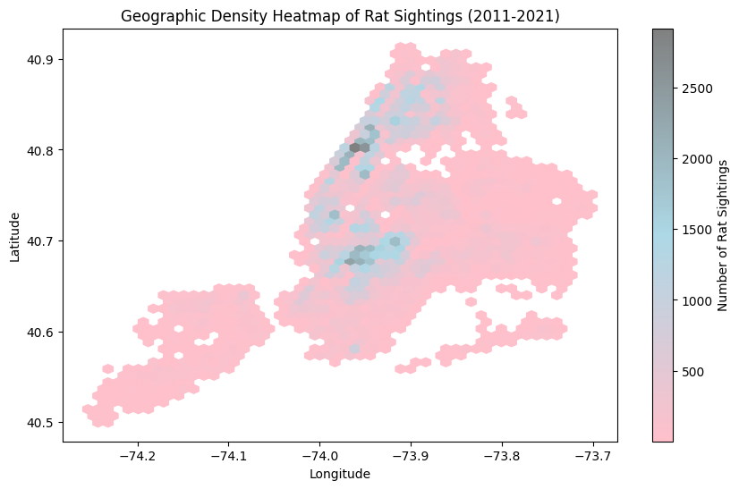

```python
import matplotlib.colors as mcolors

cmap = mcolors.LinearSegmentedColormap.from_list("custom_cmap", ["pink", "lightblue", "grey"])
plt.figure(figsize=(10, 6))
plt.hexbin(df['Longitude'], df['Latitude'], gridsize=50, cmap=cmap, mincnt=1)
plt.colorbar(label='Number of Rat Sightings')
plt.title('Geographic Density Heatmap of Rat Sightings (2011-2021)')
plt.xlabel('Longitude')
plt.ylabel('Latitude')
plt.show()
```

## Part 3: Rat Sightings over Time

In this section, we explore the patterns of rat sightings over time by extracting relevant date information from our dataset and visualizing these trends. We will focus on how rat sightings vary across different months and perform a statistical comparison between seasons—specifically, winter and summer.

Extract the month, week, and day from the dates in the dataset.

```python
# Convert 'Created Date' to datetime format
df['Created Date'] = pd.to_datetime(df['Created Date'])

# Extract month, week, and day information
df['Year'] = df['Created Date'].dt.year
df['Month'] = df['Created Date'].dt.month
df['Week'] = df['Created Date'].dt.isocalendar().week
df['Day'] = df['Created Date'].dt.day

# Check the updated dataframe
print(df[['Created Date', 'Year', 'Month', 'Week', 'Day']].head())
```

```
         Created Date  Year  Month  Week  Day
0 2024-05-31 00:10:00  2024      5    22   31
1 2024-06-01 15:01:00  2024      6    22    1
2 2024-06-06 10:08:00  2024      6    23    6
3 2024-06-25 11:34:00  2024      6    26   25
4 2024-06-27 10:48:00  2024      6    26   27
```

### Visualizing Rat sightings over Months

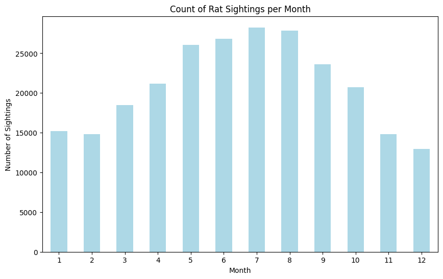

```python
# Count rat sightings per month
rat_sightings_by_month = df['Month'].value_counts().sort_index()

# Plot the results
plt.figure(figsize=(10, 6))
rat_sightings_by_month.plot(kind='bar', color='lightblue')
plt.title('Count of Rat Sightings per Month')
plt.xlabel('Month')
plt.ylabel('Number of Sightings')
plt.xticks(rotation=0)
plt.show()
```

### Visualizing Rat Sightings over Month-Years

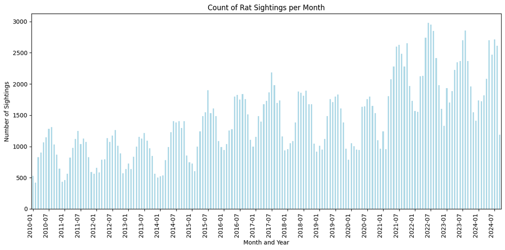

```python
# Create a 'Year-Month' column as a datetime type, and then count occurrences
df['Year-Month'] = df['Created Date'].dt.to_period('M')  # 'M' ensures a Period type (year-month)
rat_sightings_by_month = df.groupby('Year-Month').size().sort_index()

# Plotting
plt.figure(figsize=(12, 6))
ax = rat_sightings_by_month.plot(kind='bar', color='lightblue')

# Limit the number of x-axis labels
xticks_to_show = rat_sightings_by_month.index[::6]
xtick_positions = range(0, len(rat_sightings_by_month), 6)

plt.xticks(ticks=xtick_positions, labels=xticks_to_show.astype(str), ha='right')

plt.title('Count of Rat Sightings per Month')
plt.xlabel('Month and Year')
plt.ylabel('Number of Sightings')

plt.tight_layout()  # Ensures everything fits without overlap
plt.show()
```

### **TEST 1:** T-test on Summer vs Winter Rat Sightings

H0: There is no significant difference in rat sightings between winter months and summer months.

H1: There is a significant difference in rat sightings between winter months and summer months.

```python
# Compare rat sightings between Winter (Dec-Feb) and Summer (Jun-Aug)
winter_months = [12, 1, 2]
summer_months = [6, 7, 8]

# Get sightings for winter and summer
winter_sightings = df[df['Month'].isin(winter_months)]['Month'].count()
summer_sightings = df[df['Month'].isin(summer_months)]['Month'].count()

# Filter the data for winter and summer months
winter_data = df[df['Month'].isin([12, 1, 2])]
summer_data = df[df['Month'].isin([6, 7, 8])]
```

```python
# Check the length of data for both groups
print("Winter sightings count:", len(winter_data))
print("Summer sightings count:", len(summer_data))
```

```
Winter sightings count: 42933
Summer sightings count: 82968
```

```python
# Check for NaN values in these groups
print("NaN in winter data:", winter_data.isna().sum())
print("NaN in summer data:", summer_data.isna().sum())

# Drop rows with missing values in 'Incident Zip', 'Latitude', or 'Longitude'
winter_data_clean = winter_data.dropna(subset=['Incident Zip', 'Latitude', 'Longitude'])
summer_data_clean = summer_data.dropna(subset=['Incident Zip', 'Latitude', 'Longitude'])

# Check cleaned data
print("Cleaned winter data count:", len(winter_data_clean))
print("Cleaned summer data count:", len(summer_data_clean))
```

```
NaN in winter data: Created Date       0
Location Type      0
Incident Zip       0
Community Board    0
Borough            0
Latitude           0
Longitude          0
Year               0
Month              0
Week               0
Day                0
Year-Month         0
dtype: int64
NaN in summer data: Created Date       0
Location Type      0
Incident Zip       0
Community Board    0
Borough            0
Latitude           0
Longitude          0
Year               0
Month              0
Week               0
Day                0
Year-Month         0
dtype: int64
Cleaned winter data count: 42933
Cleaned summer data count: 82968
```

T test: T-test is only valid if the sample size is normally distributed and independent. By the Central Limit theorem, since the sizes of both datasets are over 30, a normal distribution can be assumed.

```python
# Count the number of sightings per day in both seasons
winter_sightings_per_day = winter_data_clean['Created Date'].dt.date.value_counts()
summer_sightings_per_day = summer_data_clean['Created Date'].dt.date.value_counts()

# Perform the t-test comparing the number of sightings per day in winter vs summer
t_stat, p_value = stats.ttest_ind(winter_sightings_per_day, summer_sightings_per_day, equal_var=False)

print(f'T-statistic: {t_stat}, P-value: {p_value}')
```

```
T-statistic: -32.5198022279798, P-value: 2.2052905701576025e-193
```

**Insights: Correlation 1**

In examining the dataset of rat sightings, it becomes evident that there is a noticeable correlation between the number of rat sightings and the seasons, particularly when comparing warmer months to colder months. The data and graph indicates that rat sightings tend to increase significantly during the warmer months of summer (June, July, and August). This trend can be attributed to several factors, including increased outdoor activity, which leads to more people being in public spaces and consequently more reports of rat sightings. Additionally, the summer months typically provide a greater abundance of food sources for rats, whether through discarded food in parks and streets or increased human activity in residential areas. Conversely, there is a decline in rat sightings during the winter months (December, January, and February), which can be explained by harsh weather conditions that limit rat activity and their ability to forage for food. Moreover, rats may seek shelter in warmer environments during the winter, such as basements or other protected areas, making them less visible or accessible to the public.

## Part 4: Rat Sightings and Location

### **Test 2**: ANOVA Test on Rat Sightings across Boroughs

The ANOVA test is used to assess if there are significant differences in average rat sightings per zip code across different boroughs. Its purpose is to compare the means of multiple groups.

H0: There are no significant differences in mean rat sightings across boroughs

H1: There are significant differences in mean rat sightings across boroughs

```python
from scipy import stats

sightings_per_zip = df.groupby(['Borough', 'Incident Zip']).size().reset_index(name='Sightings')

# group by Borough to prepare for ANOVA
sightings_by_borough = sightings_per_zip.groupby('Borough')['Sightings'].apply(list).reset_index()
print(sightings_by_borough)

# Extracting sightings lists for each borough
borough_groups = sightings_by_borough['Sightings'].tolist()

# Perform ANOVA
f_statistic, p_value = stats.f_oneway(*borough_groups)

print(f'P-value: {p_value}')
```

```
         Borough                                          Sightings
0          BRONX  [1797, 2525, 2655, 1300, 1848, 3660, 3131, 322...
1       BROOKLYN  [1996, 2260, 739, 2730, 3726, 3810, 2329, 1473...
2      MANHATTAN  [26, 8, 919, 2493, 1711, 103, 107, 165, 416, 2...
3         QUEENS  [91, 66, 17, 1401, 797, 1199, 777, 1239, 872, ...
4  STATEN ISLAND  [1031, 592, 642, 825, 900, 1208, 181, 591, 420...
P-value: 1.6924366973020327e-09
```

But first, let's visualize the results of the ANOVA Test.

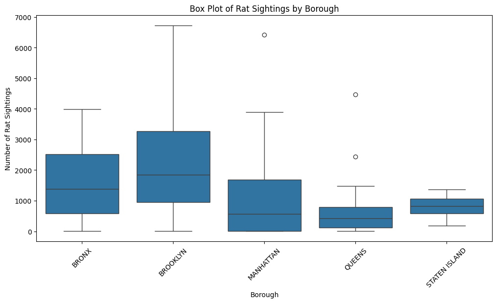

```python
import matplotlib.pyplot as plt
import seaborn as sns

plt.figure(figsize=(12, 6))
sns.boxplot(x='Borough', y='Sightings', data=sightings_per_zip)
plt.title('Box Plot of Rat Sightings by Borough')
plt.xlabel('Borough')
plt.ylabel('Number of Rat Sightings')
plt.xticks(rotation=45)
plt.show()
```

### **Follow-up** Post-hoc Test with Turkey's HSD Test

```python
import matplotlib.pyplot as plt
from statsmodels.stats.multicomp import pairwise_tukeyhsd

long_df = sightings_per_zip[['Borough', 'Sightings']].copy()
long_df = long_df.explode('Sightings').reset_index(drop=True)
long_df['Sightings'] = pd.to_numeric(long_df['Sightings'], errors='coerce')

# Perform Tukey's HSD test
tukey_results = pairwise_tukeyhsd(long_df['Sightings'], long_df['Borough'], alpha=0.05)
print(tukey_results)
```

```
         Multiple Comparison of Means - Tukey HSD, FWER=0.05
=====================================================================
  group1      group2     meandiff  p-adj    lower      upper   reject
---------------------------------------------------------------------
    BRONX      BROOKLYN   636.7036  0.184  -159.8551 1433.2623  False
    BRONX     MANHATTAN  -570.5648 0.2089 -1305.5915  164.4619  False
    BRONX        QUEENS  -975.3527  0.003 -1710.3793  -240.326   True
    BRONX STATEN ISLAND  -743.2011 0.3729 -1875.6395  389.2372  False
 BROOKLYN     MANHATTAN -1207.2684    0.0 -1858.4881 -556.0487   True
 BROOKLYN        QUEENS -1612.0563    0.0  -2263.276 -960.8366   True
 BROOKLYN STATEN ISLAND -1379.9048 0.0048 -2459.8305 -299.9791   True
MANHATTAN        QUEENS  -404.7879 0.2999  -979.1097  169.5339  False
MANHATTAN STATEN ISLAND  -172.6364 0.9908 -1208.0097   862.737  False
   QUEENS STATEN ISLAND   232.1515 0.9723  -803.2218 1267.5248  False
---------------------------------------------------------------------
```

The results do not suggest significant differences in sightings between Bronx and Brooklyn, or between some other borough pairs.

One consideration to make is the size of respective regions when interpreting these results. It would be important to incorporate this data to determine concentration of rat sightings when performing analysis within our final findings.

## Part 5: Rat Sightings in Residential vs. Non-Residential Properties

### **Test 3:** Mann-Whitney Test on Residential vs. Non-Residential Rat Sightings

```python
from scipy.stats import mannwhitneyu

residential_sightings = residential_df['Incident Zip'].value_counts()
non_residential_sightings = nonresidential_df['Incident Zip'].value_counts()

# Mann-Whitney U Test
u_stat, p_value = mannwhitneyu(residential_sightings, non_residential_sightings, alternative='two-sided')

# Output results
print(f'Mann-Whitney U Statistic: {u_stat}, P-value: {p_value}')
```

```
Mann-Whitney U Statistic: 29047.0, P-value: 5.084196762032582e-22
```

**Visualization**: We can also visualize the results from the Mann-Whitney Test using a bar graph:

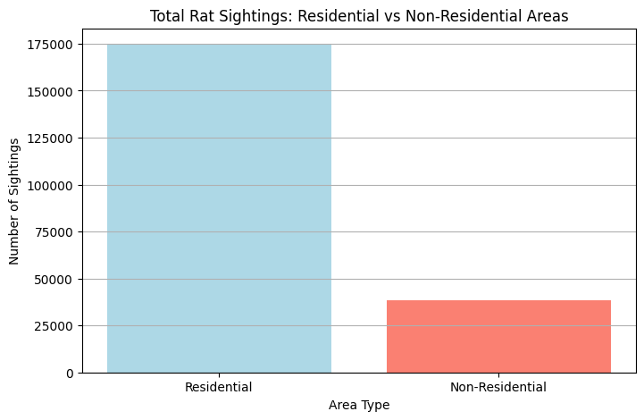

```python
# Visualization
counts = pd.DataFrame({
    'Area Type': ['Residential', 'Non-Residential'],
    'Sightings': [residential_sightings.sum(), non_residential_sightings.sum()]
})

plt.figure(figsize=(8, 5))
plt.bar(counts['Area Type'], counts['Sightings'], color=['lightblue', 'salmon'])
plt.title('Total Rat Sightings: Residential vs Non-Residential Areas')
plt.xlabel('Area Type')
plt.ylabel('Number of Sightings')
plt.xticks(rotation=0)
plt.grid(axis='y')
plt.show()
```

## Part 6: Income Dataset Cleaning, Analysis, and Merging with Rat Sightings

First, import the income and zip codes datasets.

```python
# Income data df, zipcodes for NYC boroughs, and rat sightings df
income_df = pd.read_csv("us_income_zipcode.csv")
zipcode_borough = pd.read_csv("New_York_State_ZIP_Codes-County_FIPS_Cross-Reference.csv")
```

Filter unnecessary/sparse columns from both datasets.

```python
# Drop all margin of error columns
def drop_margin_cols():
    lst = income_df.columns
    remove_list = []

    for col in lst:
        if "Margin of Error" in col:
            remove_list.append(col)
    return remove_list

lst = drop_margin_cols()
income_df.drop(lst, axis=1, inplace=True)

# Drop other columns we don't need from income
income_df.drop(["Geography", "Geographic Area Name"], axis=1, inplace=True)

# Drop columns we don't need from borough df
zipcode_borough.drop(["State FIPS", "County Code", "File Date", "County FIPS"], axis=1, inplace=True)
```

Next, merge the income and zip code datasets. This will add the County Name, a feature of the zip code datasets, to income.

```python
# Merge income_df and zipcode_borough
merged_df = income_df.merge(zipcode_borough, left_on="ZIP", right_on="ZIP Code")

# Filter to only include the 5 boroughs of NYC
merged_df = merged_df[(merged_df["County Name"] == "Bronx") | (merged_df["County Name"] == "Queens") | (merged_df["County Name"] == "New York") | (merged_df["County Name"] == "Kings") | (merged_df["County Name"] == "Richmond")]

# Drop ZIP Code since it is a redundant column
merged_df.drop("ZIP Code", axis=1, inplace=True)

# Convert year to int data type
merged_df["Year"] = merged_df["Year"].astype(int)

# Fixing households to make them ints
merged_df["Households"] = merged_df["Households"].astype(int)

# Imputation on the Married-Couple Families Mean Income (Dollars) feature for Staten Island/Richmond
merged_df.loc[merged_df['County Name'] == 'Richmond', 'Married-Couple Families Mean Income (Dollars)'] = \
    merged_df.loc[merged_df['County Name'] == 'Richmond', 'Married-Couple Families Median Income (Dollars)'] * \
    (merged_df.loc[merged_df['County Name'] == 'Richmond', 'Households Mean Income (Dollars)'] / \
     merged_df.loc[merged_df['County Name'] == 'Richmond', 'Households Median Income (Dollars)'])

# Drop remaining NA values from the merged dataset
merged_df.dropna(inplace=True)
merged_df
```

|  | ZIP | Households | Households Less Than $10,000 | Households $10,000 to $14,999 | Households $15,000 to $24,999 | Households $25,000 to $34,999 | Households $35,000 to $49,999 | Households $50,000 to $74,999 | Households $75,000 to $99,999 | Households $100,000 to $149,999 | ... | Nonfamily Households $50,000 to $74,999 | Nonfamily Households $75,000 to $99,999 | Nonfamily Households $100,000 to $149,999 | Nonfamily Households $150,000 to $199,999 | Nonfamily Households $200,000 or More | Nonfamily Households Median Income (Dollars) | Nonfamily Households Mean Income (Dollars) | Nonfamily Households Nonfamily Income in the Past 12 Months | Year | County Name |
| --- | --- | --- | --- | --- | --- | --- | --- | --- | --- | --- | --- | --- | --- | --- | --- | --- | --- | --- | --- | --- | --- |
| 2 | 10002 | 34737 | 13.0 | 11.8 | 12.9 | 10.0 | 9.1 | 11.2 | 9.2 | 9.2 | ... | 10.0 | 9.4 | 10.1 | 4.3 | 8.0 | 32489.0 | 69003.0 | 34.8 | 2021 | New York |
| 27 | 10029 | 33024 | 18.9 | 10.1 | 13.0 | 8.8 | 9.9 | 13.6 | 8.1 | 6.8 | ... | 11.2 | 8.9 | 6.1 | 3.9 | 4.3 | 24688.0 | 55232.0 | 53.1 | 2021 | New York |
| 70 | 10301 | 14308 | 8.8 | 3.8 | 5.4 | 7.5 | 8.9 | 13.9 | 11.7 | 15.6 | ... | 18.5 | 13.1 | 11.5 | 3.7 | 3.4 | 50165.0 | 64931.0 | 48.2 | 2021 | Richmond |
| 71 | 10302 | 5597 | 10.3 | 3.1 | 7.8 | 4.6 | 8.8 | 16.7 | 10.4 | 19.0 | ... | 15.8 | 8.5 | 4.3 | 4.5 | 1.9 | 25990.0 | 43308.0 | 47.4 | 2021 | Richmond |
| 72 | 10303 | 8387 | 11.0 | 5.4 | 5.2 | 5.9 | 6.1 | 18.7 | 9.7 | 17.9 | ... | 25.3 | 4.7 | 13.7 | 1.3 | 1.8 | 43654.0 | 55051.0 | 47.9 | 2021 | Richmond |
| ... | ... | ... | ... | ... | ... | ... | ... | ... | ... | ... | ... | ... | ... | ... | ... | ... | ... | ... | ... | ... | ... |
| 22073 | 11419 | 12503 | 5.2 | 4.3 | 9.6 | 12.1 | 15.0 | 18.8 | 14.8 | 12.1 | ... | 20.8 | 6.2 | 1.9 | 1.9 | 0.0 | 31296.0 | 37868.0 | 41.9 | 2011 | Queens |
| 22075 | 11421 | 12181 | 6.0 | 4.4 | 10.1 | 10.1 | 16.4 | 17.9 | 13.5 | 13.4 | ... | 14.9 | 7.6 | 5.5 | 1.0 | 0.2 | 33865.0 | 42880.0 | 35.9 | 2011 | Queens |
| 22083 | 11429 | 7690 | 5.5 | 2.4 | 5.8 | 6.2 | 10.0 | 19.5 | 16.7 | 22.5 | ... | 21.1 | 14.3 | 11.0 | 2.8 | 0.0 | 46550.0 | 53007.0 | 31.7 | 2011 | Queens |
| 22085 | 11432 | 18380 | 7.2 | 5.6 | 11.5 | 11.5 | 14.2 | 18.7 | 11.1 | 12.3 | ... | 20.0 | 10.5 | 5.0 | 1.5 | 1.1 | 35161.0 | 48278.0 | 24.4 | 2011 | Queens |
| 22088 | 11435 | 17950 | 5.6 | 6.3 | 9.8 | 10.3 | 13.8 | 21.3 | 13.9 | 12.6 | ... | 17.8 | 10.4 | 8.3 | 3.2 | 1.0 | 39375.0 | 51434.0 | 24.2 | 2011 | Queens |

576 rows × 58 columns

### EDA: Merged Rat Sightings and Income

```python
#Merging income with the rat sightings data
income_rat_df = merged_df.merge(df, left_on=["ZIP", "Year"], right_on=["Incident Zip", "Year"])

# A function to keep only the important columns and mean/median income columns for final dataframe
def save_cols():
    columns = income_rat_df.columns
    save_lst = []
    important = ["ZIP", "Households", "Year", "Created Date", "Location Type", "Community Board", "Borough", "Latitude", "Longitude"]

    for col in columns:
        if "Mean Income (Dollars)" in col or "Median Income (Dollars)" in col:
            save_lst.append(col)
        elif col in important:
            save_lst.append(col)

    return save_lst

lst = save_cols()
income_rat_df = income_rat_df[lst]
income_rat_df.dropna(inplace=True)
income_rat_df
```

|  | ZIP | Households | Households Median Income (Dollars) | Households Mean Income (Dollars) | Families Median Income (Dollars) | Families Mean Income (Dollars) | Married-Couple Families Median Income (Dollars) | Married-Couple Families Mean Income (Dollars) | Nonfamily Households Median Income (Dollars) | Nonfamily Households Mean Income (Dollars) | Year | Created Date | Location Type | Community Board | Borough | Latitude | Longitude |
| --- | --- | --- | --- | --- | --- | --- | --- | --- | --- | --- | --- | --- | --- | --- | --- | --- | --- |
| 0 | 10002 | 34737 | 37093.0 | 76115.0 | 38815.0 | 82382.0 | 51689.0 | 101513.0 | 32489.0 | 69003.0 | 2021 | 2021-01-02 11:04:00 | 3+ Family | 03 MANHATTAN | MANHATTAN | 40.712790 | -73.994416 |
| 1 | 10002 | 34737 | 37093.0 | 76115.0 | 38815.0 | 82382.0 | 51689.0 | 101513.0 | 32489.0 | 69003.0 | 2021 | 2021-01-08 22:01:00 | 3+ Family | 03 MANHATTAN | MANHATTAN | 40.720000 | -73.989949 |
| 2 | 10002 | 34737 | 37093.0 | 76115.0 | 38815.0 | 82382.0 | 51689.0 | 101513.0 | 32489.0 | 69003.0 | 2021 | 2021-01-20 09:37:00 | 3+ Family | 03 MANHATTAN | MANHATTAN | 40.721333 | -73.983336 |
| 3 | 10002 | 34737 | 37093.0 | 76115.0 | 38815.0 | 82382.0 | 51689.0 | 101513.0 | 32489.0 | 69003.0 | 2021 | 2021-01-19 14:17:00 | Other (Explain Below) | 03 MANHATTAN | MANHATTAN | 40.715378 | -73.992324 |
| 4 | 10002 | 34737 | 37093.0 | 76115.0 | 38815.0 | 82382.0 | 51689.0 | 101513.0 | 32489.0 | 69003.0 | 2021 | 2021-01-21 01:29:00 | 3+ Family | 03 MANHATTAN | MANHATTAN | 40.715874 | -73.990852 |
| ... | ... | ... | ... | ... | ... | ... | ... | ... | ... | ... | ... | ... | ... | ... | ... | ... | ... |
| 64540 | 11435 | 17950 | 54086.0 | 65131.0 | 57789.0 | 70488.0 | 67135.0 | 78335.0 | 39375.0 | 51434.0 | 2011 | 2011-12-04 00:00:00 | 1-2 Family Apartment | 12 QUEENS | QUEENS | 40.687739 | -73.802493 |
| 64541 | 11435 | 17950 | 54086.0 | 65131.0 | 57789.0 | 70488.0 | 67135.0 | 78335.0 | 39375.0 | 51434.0 | 2011 | 2011-12-06 00:00:00 | 3+ Family Mixed | 08 QUEENS | QUEENS | 40.706788 | -73.808957 |
| 64542 | 11435 | 17950 | 54086.0 | 65131.0 | 57789.0 | 70488.0 | 67135.0 | 78335.0 | 39375.0 | 51434.0 | 2011 | 2011-12-16 00:00:00 | 1-2 Family Apartment | 12 QUEENS | QUEENS | 40.691843 | -73.807817 |
| 64543 | 11435 | 17950 | 54086.0 | 65131.0 | 57789.0 | 70488.0 | 67135.0 | 78335.0 | 39375.0 | 51434.0 | 2011 | 2011-12-19 00:00:00 | Vacant Lot | 12 QUEENS | QUEENS | 40.696941 | -73.806587 |
| 64544 | 11435 | 17950 | 54086.0 | 65131.0 | 57789.0 | 70488.0 | 67135.0 | 78335.0 | 39375.0 | 51434.0 | 2011 | 2011-12-21 00:00:00 | 3+ Family | 08 QUEENS | QUEENS | 40.715034 | -73.823190 |

64545 rows × 17 columns

We are looking at residential living (families and married-couple families is considered residential in our dataset) that have a median income over 100k dollars per Borough. According to SmartAsset, "an individual needs $96,500 for sustainable comfort in a major U.S. City" (https://smartasset.com/data-studies/salary-needed-live-comfortably-2024). Considering this, we decided to choose 100k as an important median income value to look at.

We are choosing to have an alpha value of 0.05.

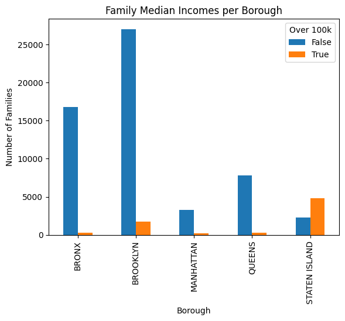

```python
# Create a column to sort over 100k and under 100k salaries
income_rat_df["Over 100k"] = (income_rat_df["Families Median Income (Dollars)"] >= 100000) | (income_rat_df["Married-Couple Families Median Income (Dollars)"] >= 100000)

# Chi-Squared test
contingency = pd.crosstab(income_rat_df["Borough"], income_rat_df["Over 100k"])
contingency.plot(kind='bar', stacked=False)

# Plot
plt.xlabel("Borough")
plt.ylabel("Number of Families")
plt.title("Family Median Incomes per Borough")
plt.show()
```

After conducting the chi-squared test, we have a p-value of 0.0. Since this value is less than our alpha value of 0.05, we choose to reject the null hypothesis. We can use this information to determine that certain Boroughs tend to be wealthier than others. In the future, we can plan to look into whether or not wealthier boroughs have a negative correlation with rat sightings.

```python
chi2_table = stats.chi2_contingency(contingency, correction=False)
chi2_table
```

```
Chi2ContingencyResult(statistic=25585.08502871283, pvalue=0.0, dof=4, expected_freq=array([[15124.53883337,  1936.46116663],
       [25516.95245178,  3267.04754822],
       [ 3082.35282361,   394.64717639],
       [ 7180.63211713,   919.36788287],
       [ 6314.52377411,   808.47622589]]))
```

```python
# Remove the column added for EDA
income_rat_df = income_rat_df.drop(columns=["Over 100k"])
```

### Prepare Merged Data for ML Analysis

We want to create a single column that gives us the average income in an area. We currently have two measures of center for the income: median and mean. As mean is dramatically influenced by skew, we decided to procede with the median as our main measure of average income.

```python
# List of median income columns
median_income_columns = [
    'Households Median Income (Dollars)',
    'Families Median Income (Dollars)',
    'Married-Couple Families Median Income (Dollars)',
    'Nonfamily Households Median Income (Dollars)'
]

# Calculate the average of the median income columns
income_rat_df['Average Income (Dollars)'] = income_rat_df[median_income_columns].mean(axis=1)

# Drop the original mean and median columns
columns_to_drop = [
    'Households Median Income (Dollars)',
    'Households Mean Income (Dollars)',
    'Families Median Income (Dollars)',
    'Families Mean Income (Dollars)',
    'Married-Couple Families Median Income (Dollars)',
    'Married-Couple Families Mean Income (Dollars)',
    'Nonfamily Households Median Income (Dollars)',
    'Nonfamily Households Mean Income (Dollars)'
]

income_rat_df = income_rat_df.drop(columns=columns_to_drop)

income_rat_df
```

|  | ZIP | Households | Year | Created Date | Location Type | Community Board | Borough | Latitude | Longitude | Average Income (Dollars) |
| --- | --- | --- | --- | --- | --- | --- | --- | --- | --- | --- |
| 0 | 10002 | 34737 | 2021 | 2021-01-02 11:04:00 | 3+ Family | 03 MANHATTAN | MANHATTAN | 40.712790 | -73.994416 | 40021.50 |
| 1 | 10002 | 34737 | 2021 | 2021-01-08 22:01:00 | 3+ Family | 03 MANHATTAN | MANHATTAN | 40.720000 | -73.989949 | 40021.50 |
| 2 | 10002 | 34737 | 2021 | 2021-01-20 09:37:00 | 3+ Family | 03 MANHATTAN | MANHATTAN | 40.721333 | -73.983336 | 40021.50 |
| 3 | 10002 | 34737 | 2021 | 2021-01-19 14:17:00 | Other (Explain Below) | 03 MANHATTAN | MANHATTAN | 40.715378 | -73.992324 | 40021.50 |
| 4 | 10002 | 34737 | 2021 | 2021-01-21 01:29:00 | 3+ Family | 03 MANHATTAN | MANHATTAN | 40.715874 | -73.990852 | 40021.50 |
| ... | ... | ... | ... | ... | ... | ... | ... | ... | ... | ... |
| 64540 | 11435 | 17950 | 2011 | 2011-12-04 00:00:00 | 1-2 Family Apartment | 12 QUEENS | QUEENS | 40.687739 | -73.802493 | 54596.25 |
| 64541 | 11435 | 17950 | 2011 | 2011-12-06 00:00:00 | 3+ Family Mixed | 08 QUEENS | QUEENS | 40.706788 | -73.808957 | 54596.25 |
| 64542 | 11435 | 17950 | 2011 | 2011-12-16 00:00:00 | 1-2 Family Apartment | 12 QUEENS | QUEENS | 40.691843 | -73.807817 | 54596.25 |
| 64543 | 11435 | 17950 | 2011 | 2011-12-19 00:00:00 | Vacant Lot | 12 QUEENS | QUEENS | 40.696941 | -73.806587 | 54596.25 |
| 64544 | 11435 | 17950 | 2011 | 2011-12-21 00:00:00 | 3+ Family | 08 QUEENS | QUEENS | 40.715034 | -73.823190 | 54596.25 |

64545 rows × 10 columns

```python
# Convert 'Created Date' to datetime format
income_rat_df['Created Date'] = pd.to_datetime(income_rat_df['Created Date'])

# Extract month and year-month information
income_rat_df['Month'] = income_rat_df['Created Date'].dt.month
income_rat_df['Year-Month'] = income_rat_df['Created Date'].dt.strftime('%B %Y')
```

## Part 7: Number of Rat Sightings vs. Population Density By Zip Code

We also have a dataset of the population densities in New York City by zip code for 2024. We merge this data with the rat sightings data from 2024 to detect any linear correlation between the population density and the number of rat sightings reported.

```python
import numpy as np

# Get population density dataset
pop_density_df = pd.read_csv("uszips.csv")
pop_density_df = pop_density_df[['zip', 'density']]

# Filter on 2024 data since the population density data is only for 2024
pop_merged_df = pd.merge(pop_density_df, df[df['Created Date'].dt.year == 2024], left_on='zip', right_on='Incident Zip', how='inner')

# Get number of sightings per zip code, keeping numerical order of zip
groups = pop_merged_df.groupby('zip', as_index=False)
num_sightings = groups.size().sort_values('zip', ascending=True)

# Get unique list of zip codes in numerical order
pop_merged_df.sort_values('zip', ascending=True, inplace=True)
zips = pop_merged_df['zip'].unique()

# Get corresponding densities of the ordered zips
pop_merged_df = pop_merged_df.drop_duplicates(subset='zip', keep="first").sort_values('zip', ascending=True)

x = pop_merged_df['density']
y = num_sightings['size']

# Pearson correlation coefficient
print("Correlation Coefficient: " + str(np.corrcoef(x, y)[0, 1]))
```

```
Correlation Coefficient: 0.2910724813487177
```

The two datasets are merged on the zip code, and we find the number of sightings and the population density of each zip code, totaling 180 data points.

We find the Pearson correlation coefficient to be 0.291, indicating a weak positive linear correlation between population density and number of rat sightings. We can conclude that the number of rat sightings does not consistently linearly increase as the population density increases. Due to the weak correlation and the lack of population density data per year (only census data is available), we will not continue with this dataset.

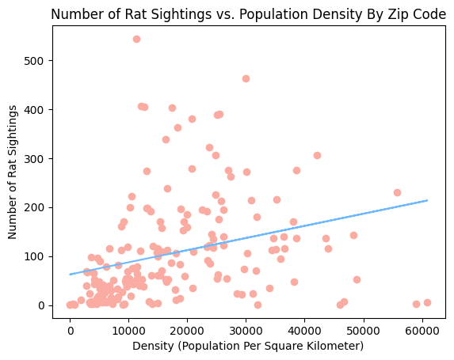

```python
# Plot number of sightings vs. population density of zip
a, b = np.polyfit(x, y, 1)

plt.scatter(x, y, color='#faaba2')
plt.plot(x, a*x+b, color='#6eb9ff') # line of best fit
plt.xlabel("Density (Population Per Square Kilometer)")
plt.ylabel("Number of Rat Sightings")
plt.title("Number of Rat Sightings vs. Population Density By Zip Code")
plt.show()
```

This is a scatterplot with the population density on the x-axis and the number of rat sightings on the y-axis. We observe visually that the distribution has more of a bell-curve shape, which may be explained by the Central Limit Theorem acting upon other factors to produce a normal distribution.

## Part 8: EDA Conclusion

Our analysis explored rat sightings across New York City across the years 2011-2021, investigating the impact of geographic location, income levels, and population density. The goal of this analysis was to identify significant patterns in rat sightings that could better inform public health strategies and urban planning.

In addition to the geographic analysis, we compared rat sightings in residential and non-residential areas using the Mann-Whitney U test. The results indicated a significant difference, with residential areas reporting more rat sightings than non-residential ones. This points to a potential public health concern, as rats in residential areas may pose more direct risks to human health. These findings emphasize the importance of focusing on residential infestations when implementing pest control measures and public health interventions.

Further analysis was conducted by merging rat sighting data with U.S. Census income data to investigate the relationship between income and rat infestations. A chi-squared test showed that wealthier boroughs tend to have more families with median incomes above $100,000, highlighting the economic disparities across the city. Although this test did not directly link income to rat sightings, it provides a basis for future research into whether wealthier areas experience fewer rat infestations due to better infrastructure and services. The relationship between income levels and the frequency of rat sightings warrants further exploration.

Finally, we examined the correlation between population density and rat sightings. The Pearson correlation coefficient indicated a weak positive relationship between the two variables, suggesting that while rat sightings tend to increase with population density, the correlation is not strong. This analysis also revealed a bell-curve pattern, implying that other factors, such as urban infrastructure and waste management, may be more influential than population density alone in determining the prevalence of rats.

In summary, our research highlights the multifaceted nature of rat infestations in New York City. As geographic location, residential versus non-residential areas, and socioeconomic factors all contribute to the distribution of rat sightings, we made sure to find accurate and reliable datasets and manipulated them to better analyze the impact of rat infestations on public hygiene and general human health. While population density shows a weak correlation with sightings, other underlying factors likely play a role in the occurrence of rats. In the future, we plan to include population density or physical square footage when comparing boroughs to gain more accurate insights. Additionally, we will analyze income ranges and examine the correlation coefficients across various categories to identify key patterns. We'll also investigate how income levels correspond with reported sightings. Finally, we will merge all of our datasets to conduct a comprehensive analysis and uncover deeper relationships between these variables.

# Primary Analysis, ML Model, & Visualization

Here, we start off by preparing our dataset for the machine learning model.

```python
rat_sightings_by_month = income_rat_df['Year-Month'].value_counts().sort_index()
quantiles = pd.qcut(rat_sightings_by_month, 3, labels=["Low", "Medium", "High"])
rat_sightings_by_month_category = quantiles
category_mapping = rat_sightings_by_month_category.to_dict()

income_rat_df['Rat Concentration'] = income_rat_df['Year-Month'].map(category_mapping)

income_rat_df
```

|  | ZIP | Households | Year | Created Date | Location Type | Community Board | Borough | Latitude | Longitude | Average Income (Dollars) | Month | Year-Month | Rat Concentration |
| --- | --- | --- | --- | --- | --- | --- | --- | --- | --- | --- | --- | --- | --- |
| 0 | 10002 | 34737 | 2021 | 2021-01-02 11:04:00 | 3+ Family | 03 MANHATTAN | MANHATTAN | 40.712790 | -73.994416 | 40021.50 | 1 | January 2021 | Low |
| 1 | 10002 | 34737 | 2021 | 2021-01-08 22:01:00 | 3+ Family | 03 MANHATTAN | MANHATTAN | 40.720000 | -73.989949 | 40021.50 | 1 | January 2021 | Low |
| 2 | 10002 | 34737 | 2021 | 2021-01-20 09:37:00 | 3+ Family | 03 MANHATTAN | MANHATTAN | 40.721333 | -73.983336 | 40021.50 | 1 | January 2021 | Low |
| 3 | 10002 | 34737 | 2021 | 2021-01-19 14:17:00 | Other (Explain Below) | 03 MANHATTAN | MANHATTAN | 40.715378 | -73.992324 | 40021.50 | 1 | January 2021 | Low |
| 4 | 10002 | 34737 | 2021 | 2021-01-21 01:29:00 | 3+ Family | 03 MANHATTAN | MANHATTAN | 40.715874 | -73.990852 | 40021.50 | 1 | January 2021 | Low |
| ... | ... | ... | ... | ... | ... | ... | ... | ... | ... | ... | ... | ... | ... |
| 64540 | 11435 | 17950 | 2011 | 2011-12-04 00:00:00 | 1-2 Family Apartment | 12 QUEENS | QUEENS | 40.687739 | -73.802493 | 54596.25 | 12 | December 2011 | Low |
| 64541 | 11435 | 17950 | 2011 | 2011-12-06 00:00:00 | 3+ Family Mixed | 08 QUEENS | QUEENS | 40.706788 | -73.808957 | 54596.25 | 12 | December 2011 | Low |
| 64542 | 11435 | 17950 | 2011 | 2011-12-16 00:00:00 | 1-2 Family Apartment | 12 QUEENS | QUEENS | 40.691843 | -73.807817 | 54596.25 | 12 | December 2011 | Low |
| 64543 | 11435 | 17950 | 2011 | 2011-12-19 00:00:00 | Vacant Lot | 12 QUEENS | QUEENS | 40.696941 | -73.806587 | 54596.25 | 12 | December 2011 | Low |
| 64544 | 11435 | 17950 | 2011 | 2011-12-21 00:00:00 | 3+ Family | 08 QUEENS | QUEENS | 40.715034 | -73.823190 | 54596.25 | 12 | December 2011 | Low |

64545 rows × 13 columns

```python
# Count the number of rows for each value in the "Rat Concentration" column
rat_concentration_counts = income_rat_df['Rat Concentration'].value_counts()

# Print the counts for each value
print(rat_concentration_counts)
```

```
Rat Concentration
High      29390
Medium    21346
Low       13809
Name: count, dtype: int64
```

```python
# Define summer months
summer_months = [6, 7, 8]

# Add a new column for summer (1 for summer, 0 for others)
income_rat_df['Is_Summer'] = income_rat_df['Month'].apply(lambda x: 1 if x in summer_months else 0)

# Check the updated DataFrame
income_rat_df
```

|  | ZIP | Households | Year | Created Date | Location Type | Community Board | Borough | Latitude | Longitude | Average Income (Dollars) | Month | Year-Month | Rat Concentration | Is_Summer |
| --- | --- | --- | --- | --- | --- | --- | --- | --- | --- | --- | --- | --- | --- | --- |
| 0 | 10002 | 34737 | 2021 | 2021-01-02 11:04:00 | 3+ Family | 03 MANHATTAN | MANHATTAN | 40.712790 | -73.994416 | 40021.50 | 1 | January 2021 | Low | 0 |
| 1 | 10002 | 34737 | 2021 | 2021-01-08 22:01:00 | 3+ Family | 03 MANHATTAN | MANHATTAN | 40.720000 | -73.989949 | 40021.50 | 1 | January 2021 | Low | 0 |
| 2 | 10002 | 34737 | 2021 | 2021-01-20 09:37:00 | 3+ Family | 03 MANHATTAN | MANHATTAN | 40.721333 | -73.983336 | 40021.50 | 1 | January 2021 | Low | 0 |
| 3 | 10002 | 34737 | 2021 | 2021-01-19 14:17:00 | Other (Explain Below) | 03 MANHATTAN | MANHATTAN | 40.715378 | -73.992324 | 40021.50 | 1 | January 2021 | Low | 0 |
| 4 | 10002 | 34737 | 2021 | 2021-01-21 01:29:00 | 3+ Family | 03 MANHATTAN | MANHATTAN | 40.715874 | -73.990852 | 40021.50 | 1 | January 2021 | Low | 0 |
| ... | ... | ... | ... | ... | ... | ... | ... | ... | ... | ... | ... | ... | ... | ... |
| 64540 | 11435 | 17950 | 2011 | 2011-12-04 00:00:00 | 1-2 Family Apartment | 12 QUEENS | QUEENS | 40.687739 | -73.802493 | 54596.25 | 12 | December 2011 | Low | 0 |
| 64541 | 11435 | 17950 | 2011 | 2011-12-06 00:00:00 | 3+ Family Mixed | 08 QUEENS | QUEENS | 40.706788 | -73.808957 | 54596.25 | 12 | December 2011 | Low | 0 |
| 64542 | 11435 | 17950 | 2011 | 2011-12-16 00:00:00 | 1-2 Family Apartment | 12 QUEENS | QUEENS | 40.691843 | -73.807817 | 54596.25 | 12 | December 2011 | Low | 0 |
| 64543 | 11435 | 17950 | 2011 | 2011-12-19 00:00:00 | Vacant Lot | 12 QUEENS | QUEENS | 40.696941 | -73.806587 | 54596.25 | 12 | December 2011 | Low | 0 |
| 64544 | 11435 | 17950 | 2011 | 2011-12-21 00:00:00 | 3+ Family | 08 QUEENS | QUEENS | 40.715034 | -73.823190 | 54596.25 | 12 | December 2011 | Low | 0 |

64545 rows × 14 columns

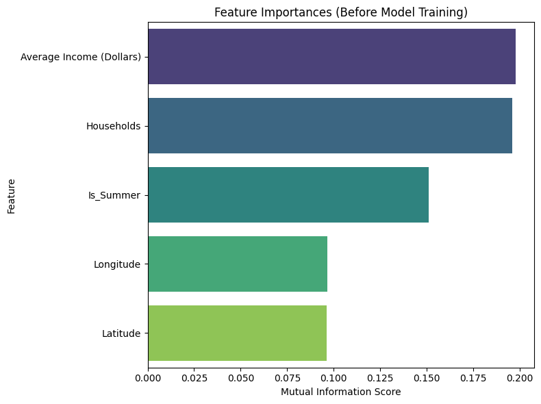

```python
import pandas as pd
import numpy as np
from sklearn.ensemble import RandomForestClassifier
from sklearn.model_selection import train_test_split
from sklearn.metrics import classification_report, confusion_matrix
from sklearn.feature_selection import mutual_info_classif
import matplotlib.pyplot as plt
import seaborn as sns

# Function to analyze feature importances before training the model
def analyze_feature_importances(income_rat_df):
    # Select features and target variable
    features = ['Latitude', 'Longitude', 'Average Income (Dollars)', 'Households', 'Is_Summer']
    target = 'Rat Concentration'
    X = income_rat_df[features]
    y = income_rat_df[target]

    # Encode the target variable if necessary
    if y.dtype == 'object' or y.dtype.name == 'category':
        y = y.astype('category').cat.codes  # Converts high/medium/low to integers

    # Calculate mutual information scores
    mutual_info = mutual_info_classif(X, y, random_state=42)
    feature_importance_df = pd.DataFrame({
        'Feature': features,
        'Importance': mutual_info
    }).sort_values(by='Importance', ascending=False)

    # Visualize feature importances
    plt.figure(figsize=(8, 6))
    sns.barplot(x='Importance', y='Feature', data=feature_importance_df, palette='viridis')
    plt.title('Feature Importances (Before Model Training)')
    plt.xlabel('Mutual Information Score')
    plt.ylabel('Feature')
    plt.tight_layout()
    plt.show()

    return feature_importance_df

# Analyze feature importances before training
pre_training_importances = analyze_feature_importances(income_rat_df)
```